# BIOSTAT 203B HW1 Solutions

George Dewey

UID: 704528320

### Question 2.1

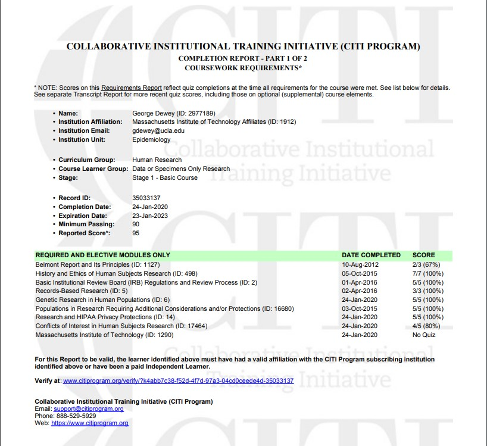

CITI Training Cert for George Dewey

### Question 2.3

The provided bash code provides the direct file path of the files located in the `/home/203bdata/mimic-iii/` directory.

```bash
for datafile in /home/203bdata/mimic-iii/*.csv
  do
    ls $datafile
  done
```

```
## /home/203bdata/mimic-iii/ADMISSIONS.csv
## /home/203bdata/mimic-iii/CALLOUT.csv
## /home/203bdata/mimic-iii/CAREGIVERS.csv
## /home/203bdata/mimic-iii/CHARTEVENTS.csv
## /home/203bdata/mimic-iii/CPTEVENTS.csv
## /home/203bdata/mimic-iii/DATETIMEEVENTS.csv
## /home/203bdata/mimic-iii/D_CPT.csv
## /home/203bdata/mimic-iii/DIAGNOSES_ICD.csv
## /home/203bdata/mimic-iii/D_ICD_DIAGNOSES.csv
## /home/203bdata/mimic-iii/D_ICD_PROCEDURES.csv
## /home/203bdata/mimic-iii/D_ITEMS.csv
## /home/203bdata/mimic-iii/D_LABITEMS.csv
## /home/203bdata/mimic-iii/DRGCODES.csv
## /home/203bdata/mimic-iii/ICUSTAYS.csv
## /home/203bdata/mimic-iii/INPUTEVENTS_CV.csv
## /home/203bdata/mimic-iii/INPUTEVENTS_MV.csv
## /home/203bdata/mimic-iii/LABEVENTS.csv
## /home/203bdata/mimic-iii/MICROBIOLOGYEVENTS.csv
## /home/203bdata/mimic-iii/NOTEEVENTS.csv
## /home/203bdata/mimic-iii/OUTPUTEVENTS.csv
## /home/203bdata/mimic-iii/PATIENTS.csv
## /home/203bdata/mimic-iii/PRESCRIPTIONS.csv
## /home/203bdata/mimic-iii/PROCEDUREEVENTS_MV.csv
## /home/203bdata/mimic-iii/PROCEDURES_ICD.csv
## /home/203bdata/mimic-iii/SERVICES.csv
## /home/203bdata/mimic-iii/TRANSFERS.csv
```

The number of lines in each csv file can can be generated with the following:

```bash
for datafile in /home/203bdata/mimic-iii/*.csv
  do
    awk 'END { print NR }' $datafile
  done
```

```
## 58977
## 34500
## 7568
## 1048576
## 573147
## 4485938
## 135
## 651048
## 14568
## 3883
## 12488
## 754
## 125558
## 61533
## 17527936
## 3618992
## 27854056
## 631727
## 91691299
## 4349219
## 46521
## 4156451
## 258067
## 240096
## 73344
## 261898
```

### Question 2.4

Display the first 10 lines of ADMISSIONS.csv with:

```bash
head /home/203bdata/mimic-iii/ADMISSIONS.csv
```

```
## "ROW_ID","SUBJECT_ID","HADM_ID","ADMITTIME","DISCHTIME","DEATHTIME","ADMISSION_TYPE","ADMISSION_LOCATION","DISCHARGE_LOCATION","INSURANCE","LANGUAGE","RELIGION","MARITAL_STATUS","ETHNICITY","EDREGTIME","EDOUTTIME","DIAGNOSIS","HOSPITAL_EXPIRE_FLAG","HAS_CHARTEVENTS_DATA"
## 21,22,165315,2196-04-09 12:26:00,2196-04-10 15:54:00,,"EMERGENCY","EMERGENCY ROOM ADMIT","DISC-TRAN CANCER/CHLDRN H","Private",,"UNOBTAINABLE","MARRIED","WHITE",2196-04-09 10:06:00,2196-04-09 13:24:00,"BENZODIAZEPINE OVERDOSE",0,1
## 22,23,152223,2153-09-03 07:15:00,2153-09-08 19:10:00,,"ELECTIVE","PHYS REFERRAL/NORMAL DELI","HOME HEALTH CARE","Medicare",,"CATHOLIC","MARRIED","WHITE",,,"CORONARY ARTERY DISEASE\CORONARY ARTERY BYPASS GRAFT/SDA",0,1
## 23,23,124321,2157-10-18 19:34:00,2157-10-25 14:00:00,,"EMERGENCY","TRANSFER FROM HOSP/EXTRAM","HOME HEALTH CARE","Medicare","ENGL","CATHOLIC","MARRIED","WHITE",,,"BRAIN MASS",0,1
## 24,24,161859,2139-06-06 16:14:00,2139-06-09 12:48:00,,"EMERGENCY","TRANSFER FROM HOSP/EXTRAM","HOME","Private",,"PROTESTANT QUAKER","SINGLE","WHITE",,,"INTERIOR MYOCARDIAL INFARCTION",0,1
## 25,25,129635,2160-11-02 02:06:00,2160-11-05 14:55:00,,"EMERGENCY","EMERGENCY ROOM ADMIT","HOME","Private",,"UNOBTAINABLE","MARRIED","WHITE",2160-11-02 01:01:00,2160-11-02 04:27:00,"ACUTE CORONARY SYNDROME",0,1
## 26,26,197661,2126-05-06 15:16:00,2126-05-13 15:00:00,,"EMERGENCY","TRANSFER FROM HOSP/EXTRAM","HOME","Medicare",,"CATHOLIC","SINGLE","UNKNOWN/NOT SPECIFIED",,,"V-TACH",0,1
## 27,27,134931,2191-11-30 22:16:00,2191-12-03 14:45:00,,"NEWBORN","PHYS REFERRAL/NORMAL DELI","HOME","Private",,"CATHOLIC",,"WHITE",,,"NEWBORN",0,1
## 28,28,162569,2177-09-01 07:15:00,2177-09-06 16:00:00,,"ELECTIVE","PHYS REFERRAL/NORMAL DELI","HOME HEALTH CARE","Medicare",,"CATHOLIC","MARRIED","WHITE",,,"CORONARY ARTERY DISEASE\CORONARY ARTERY BYPASS GRAFT/SDA",0,1
## 29,30,104557,2172-10-14 14:17:00,2172-10-19 14:37:00,,"URGENT","TRANSFER FROM HOSP/EXTRAM","HOME HEALTH CARE","Medicare",,"CATHOLIC","MARRIED","UNKNOWN/NOT SPECIFIED",,,"UNSTABLE ANGINA\CATH",0,1
```

From :

```bash
awk 'END { print NR }' /home/203bdata/mimic-iii/ADMISSIONS.csv
```

```
## 58977
```

There are **58977** lines in ADMISSIONS.csv.

The number of unique patients in the dataset can be given by:

```bash
awk -F ',' '{print $2}' /home/203bdata/mimic-iii/ADMISSIONS.csv | uniq | wc -l
```

```
## 47107
```

To obtain the possible values for each category, we can use

```bash
awk -F ',' '{if (NR!=1) {print $N}}' /home/203bdata/mimic-iii/ADMISSIONS.csv | sort | uniq
```

and change the column number `N`.

Thus for column 10 `INSURANCE` the possible values are:

```bash
awk -F ',' '{if (NR!=1) {print $10}}' /home/203bdata/mimic-iii/ADMISSIONS.csv | sort | uniq
```

```
## "Government"
## "Medicaid"
## "Medicare"
## "Private"
## "Self Pay"
```

For column 11 `LANGUAGE`:

```bash
awk -F ',' '{if (NR!=1) {print $11}}' /home/203bdata/mimic-iii/ADMISSIONS.csv | sort | uniq
```

```
##
## "ALBA"
## "AMER"
## "*AMH"
## "*ARA"
## "ARAB"
## "*ARM"
## "* BE"
## "*BEN"
## "BENG"
## "*BOS"
## "*BUL"
## "*BUR"
## "CAMB"
## "*CAN"
## "CANT"
## "CAPE"
## "*CDI"
## "*CHI"
## "*CRE"
## "*DEA"
## "*DUT"
## "ENGL"
## "ETHI"
## "*FAR"
## "*FIL"
## "FREN"
## "* FU"
## "*FUL"
## "GERM"
## "GREE"
## "*GUJ"
## "HAIT"
## "HIND"
## "*HUN"
## "*IBO"
## "ITAL"
## "JAPA"
## "*KHM"
## "KORE"
```

[output cut: 21 more lines]

```
## "SPAN"
## "** T"
## "TAGA"
## "*TAM"
## "*TEL"
## "THAI"
## "**TO"
## "*TOI"
## "*TOY"
## "TURK"
## "*URD"
## "URDU"
## "VIET"
## "*YID"
## "*YOR"
```

For column 12 `RELIGION`:

```bash
awk -F ',' '{if (NR!=1) {print $12}}' /home/203bdata/mimic-iii/ADMISSIONS.csv | sort | uniq
```

```
##
## "7TH DAY ADVENTIST"
## "BAPTIST"
## "BUDDHIST"
## "CATHOLIC"
## "CHRISTIAN SCIENTIST"
## "EPISCOPALIAN"
## "GREEK ORTHODOX"
## "HEBREW"
## "HINDU"
## "JEHOVAH'S WITNESS"
## "JEWISH"
## "LUTHERAN"
## "METHODIST"
## "MUSLIM"
## "NOT SPECIFIED"
## "OTHER"
## "PROTESTANT QUAKER"
## "ROMANIAN EAST. ORTH"
## "UNITARIAN-UNIVERSALIST"
## "UNOBTAINABLE"
```

For column 13 `MARITAL_STATUS`:

```bash
awk -F ',' '{if (NR!=1) {print $13}}' /home/203bdata/mimic-iii/ADMISSIONS.csv | sort | uniq
```

```
##
## "DIVORCED"
## "LIFE PARTNER"
## "MARRIED"
## "SEPARATED"
## "SINGLE"
## "UNKNOWN (DEFAULT)"
## "WIDOWED"
```

And for column 14 `ETHNICITY`:

```bash
awk -F ',' '{if (NR!=1) {print $14}}' /home/203bdata/mimic-iii/ADMISSIONS.csv | sort | uniq
```

```
## "AMERICAN INDIAN/ALASKA NATIVE"
## "AMERICAN INDIAN/ALASKA NATIVE FEDERALLY RECOGNIZED TRIBE"
## "ASIAN"
## "ASIAN - ASIAN INDIAN"
## "ASIAN - CAMBODIAN"
## "ASIAN - CHINESE"
## "ASIAN - FILIPINO"
## "ASIAN - JAPANESE"
## "ASIAN - KOREAN"
## "ASIAN - OTHER"
## "ASIAN - THAI"
## "ASIAN - VIETNAMESE"
## "BLACK/AFRICAN"
## "BLACK/AFRICAN AMERICAN"
## "BLACK/CAPE VERDEAN"
## "BLACK/HAITIAN"
## "CARIBBEAN ISLAND"
## "HISPANIC/LATINO - CENTRAL AMERICAN (OTHER)"
## "HISPANIC/LATINO - COLOMBIAN"
## "HISPANIC/LATINO - CUBAN"
## "HISPANIC/LATINO - DOMINICAN"
## "HISPANIC/LATINO - GUATEMALAN"
## "HISPANIC/LATINO - HONDURAN"
## "HISPANIC/LATINO - MEXICAN"
## "HISPANIC/LATINO - PUERTO RICAN"
## "HISPANIC/LATINO - SALVADORAN"
## "HISPANIC OR LATINO"
## "MIDDLE EASTERN"
## "MULTI RACE ETHNICITY"
## "NATIVE HAWAIIAN OR OTHER PACIFIC ISLANDER"
## "OTHER"
## "PATIENT DECLINED TO ANSWER"
## "PORTUGUESE"
## "SOUTH AMERICAN"
## "UNABLE TO OBTAIN"
## "UNKNOWN/NOT SPECIFIED"
## "WHITE"
## "WHITE - BRAZILIAN"
## "WHITE - EASTERN EUROPEAN"
## "WHITE - OTHER EUROPEAN"
## "WHITE - RUSSIAN"
```

### Question 3.1

After running this code:

```bash
for character in "Elizabeth" "Jane" "Lydia" "Darcy"
  do
    printf "%-10s" $character
    grep -oE $character pride_and_prejudice | wc -l
  done
```

We obtain:

```
## Elizabeth 634
## Jane      294
## Lydia     170
## Darcy     417
```

Thus Elizabeth was the most mentioned.

### Question 3.2

The command `echo 'hello, world' > test1.txt` overwrites anything in the file `test1.txt` with the text “hello, world”. The other command `echo 'hello, world' >> test2.txt` appends the text “hello, world” to the file `test2.txt`.

### Question 3.3

The output returns the `$2-$3` lines of file `$1`. The fields `$1`, `$2`, and `$3` serve as placeholders for the arguments the user must input to run the script. The numeric arguments indicate the input positions for each argument (i.e. $1 is the first input, $2 is the second, etc.)

```
Author: Jane Austen

Editor: R. W. (Robert William) Chapman
```

The purpose of the first line of the script is to tell the operating system what shell to run the script in (in this case the `sh` shell).

### Question 4.1

Below is the updated runSim script:

```r
## parsing command arguments
for (arg in commandArgs(TRUE)) {
  eval(parse(text=arg))
}

## set the random seed
set.seed(seed)

## initialize MSE
mseSampAvg = 0
msePrimeAvg = 0

for (r in 1:rep){
  ## parse distribution information
  if (dist == "gaussian"){
  ## simulate data
    x = rnorm(n)
  }
  else if (dist == "t1"){
    x = rt(n, df=1)
  }
  else if (dist == "t5"){
    x = rt(n, df=5)
  }
  else {
    # print error message if wrong distribution entered
    stop("Wrong distribution specified. Try 'gaussian', 't1', or 't5'")
  }
  mseSampAvg = mseSampAvg + mean(x)^2
  msePrimeAvg = msePrimeAvg + estMeanPrimes(x)^2
}

## check if a given integer is prime
isPrime = function(n) {
  if (n <= 3) {
    return (TRUE)
  }
  if (any((n %% 2:floor(sqrt(n))) == 0)) {
    return (FALSE)
  }
  return (TRUE)
}

## estimate mean only using observation with prime indices
estMeanPrimes = function (x) {
  n = length(x)
  ind = sapply(1:n, isPrime)
  return (mean(x[ind]))
}

# print estimators
print(msePrimeAvg/rep)
print(mseSampAvg/rep)
```

### Question 4.2

Below is the updated autoSim script:

```r
## parse command arguments
for (arg in commandArgs(TRUE)) {
  eval(parse(text=arg))
}

## initialize parameters for simulation
nVals = seq(100, 500, by=100)
distTypes = c("gaussian", "t1", "t5")

## loop through each combination of distribution/sample size
for (dist in distTypes){
  for (n in nVals) {
    # create system call argument
    arg = paste("n=", n, " dist=", shQuote(shQuote(dist)), " seed=", seed, " rep=", rep, sep="")
    # create output filenames
    oFile = paste("n", n, "_dist_", dist, ".txt", sep="")
    # call system to run runSim script to generate simulated estimates
    sysCall = paste("nohup Rscript runSim_4.1.R ", arg, " > ", oFile, sep="")
    system(sysCall, wait=F)
    print(paste("sysCall=", sysCall, sep=""))
  }
}
```

### Question 4.3

```r
## Grab a vector of filenames with the appropriate extension and name
gaussian_files = list.files(path = ".", pattern = "*_gaussian.txt", full.names=T, recursive=F)
simValsGaussian = lapply(gaussian_files, read.table, header=F)
inter1 = as.data.frame(simValsGaussian)

## These are the columns from read.table that we want to keep
keep = c("V2", "V2.1", "V2.2", "V2.3", "V2.4")
inter1 = inter1[,keep]

## Stack columns into a single column
first_col = stack(inter1)
first_col = as.data.frame(first_col[,1])

## Repeat for T5 and T1 output files
t5_files = list.files(path = ".", pattern = "*_t5.txt", full.names=T, recursive=F)
simValsT5 = lapply(t5_files, read.table, header=F)
inter2 = as.data.frame(simValsT5)
inter2 = inter2[,keep]

second_col = stack(inter2)
second_col = as.data.frame(second_col[,1])

t1_files = list.files(path = ".", pattern = "*_t1.txt", full.names=T, recursive=F)
simValsT1 = lapply(t1_files, read.table, header=F)
inter3 = as.data.frame(simValsT1)

inter3 = inter3[,keep]
third_col = stack(inter3)
third_col = as.data.frame(third_col[,1])

## Create other table columns
n_col = c(100, 100, 200, 200, 300, 300, 400, 400, 500, 500)
method_col = rep(c("PrimeAvg", "SampleAvg"), 5)

## Merge columns and rename
final_table = data.frame(n_col, method_col, first_col, second_col, third_col)
colnames(final_table) = c("N", "Method", "Gaussian", "T5", "T1")

## Display final table
final_table
```

```
##      N    Method    Gaussian          T5        T1
## 1  100  PrimeAvg 0.039264580 0.047281910  43.72672
## 2  100 SampleAvg 0.011464430 0.011320570  26.76927
## 3  200  PrimeAvg 0.024001610 0.043965280  20.91532
## 4  200 SampleAvg 0.005764383 0.006573672  43.41982
## 5  300  PrimeAvg 0.020514360 0.042466820 116.39670
## 6  300 SampleAvg 0.004199221 0.004420692 138.45650
## 7  400  PrimeAvg 0.013456000 0.027956910  48.29149
## 8  400 SampleAvg 0.002870221 0.003922553  76.24066
## 9  500  PrimeAvg 0.009396678 0.019900230 152.80850
## 10 500 SampleAvg 0.002191460 0.003111203  53.47290
```